# Part 2: Ordinary differential equations

C. Practice: modeling bacterial growth

Mingyang Lu

01/23/2022

In this section, we will illustrate the use of ODEs to model bacterial growth and leave some exercises for readers to practice.

## Exponential growth

#### Analytical solution

The simplest model considers constant [per capita](https://en.wikipedia.org/wiki/Per_capita) growth rate, $r$. The following differential equation describes the rate of change of bacterial counts, $N$, as the function of time, $t$.

$$\begin{equation}
\frac{dN}{dt} = rN \tag{1}
\end{equation}$$

The initial condition of Equation (1) is

$$N(t = 0) = N_0$$
This ODE can be solved analytically, with the solution

$$\begin{equation}
N = N_0 e^{rt} \tag{2}
\end{equation}$$

We can evaluate $N(t)$ numerically using R, as shown below.

```r
N_t_exact <- function(t,r,N0) {   # the function to calculate N(t): exact solution
  return(N0*exp(r*t))
}

r = 0.1; N0 = 1     # specify the parameter r and the initial condition N0

N_t_exact(t=0, r, N0)   # checking: the initial condition
```

```
## [1] 1
```

```r
N_t_exact(t=1, r, N0)   # checking:  t = 1
```

```
## [1] 1.105171
```

```r
N_t_exact(t=10, r, N0)   # checking:  t = 10
```

```
## [1] 2.718282
```

```r
N_t_exact(t=20, r, N0)   # checking:  t = 20
```

```
## [1] 7.389056
```

```r
N_t_exact(t=50, r, N0)   # checking:  t = 50
```

```
## [1] 148.4132
```

Note: be careful to interpret $N$ as fractional numbers.

We can also use an array to systematically apply *N_t_exact* to a series of $t$ values:

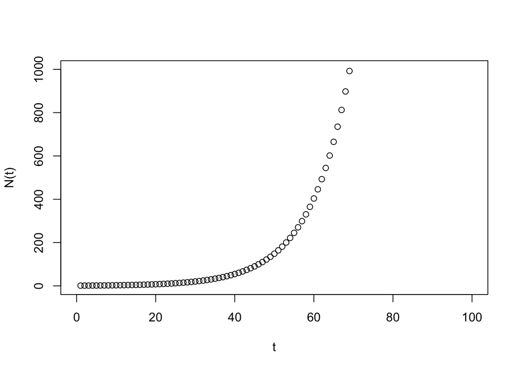

```r
t = seq(1, 100, 1)   # all time points to be evaluated
nt1 = N_t_exact(t, r, N0)   # all N(t) values

plot(t, nt1, xlab="t", ylab="N(t)", xlim=c(0,100), ylim=c(0,1000))
```

Another way to evaluate the results is to check t-log(N) plot (log scale in the N axis).

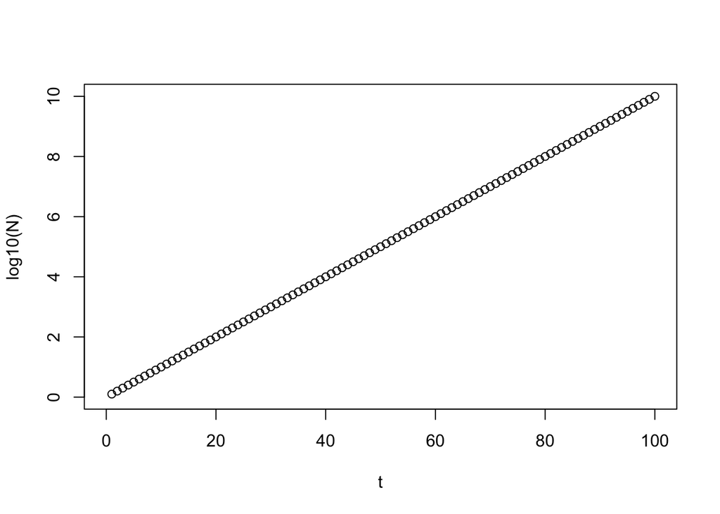

```r
plot(t, log(nt1), xlab="t", ylab="log10(N)", xlim=c(0,100), ylim=c(0,10))
```

Note: we can also generate the plot without directly converting the values in the log scale. To do so, use the argument **log=‘y’** in the plot function. (Try this! Debug if needed)

#### Use deSolve

Now, we show how to simulate Equation (1) with an ODE solver. We will first use the package deSolve. The selected integration method is the Euler method.

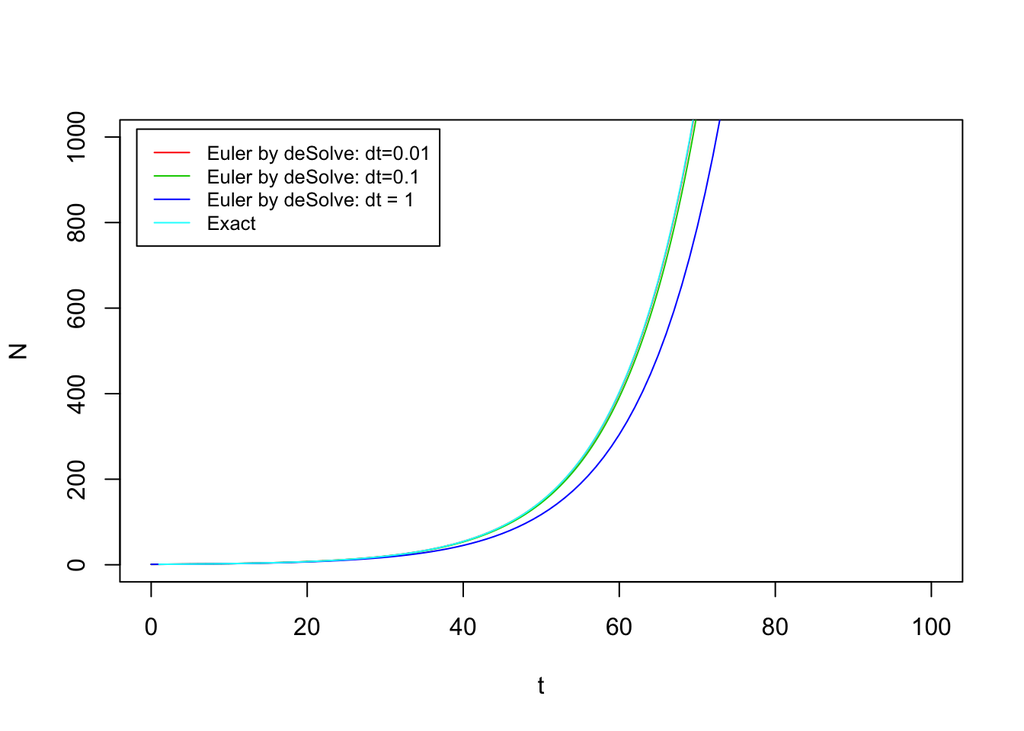

```r
library(deSolve)  # a general ode solver
?deSolve # check the help page if needed
dN_deSolve <- function(t, N, parameters) {
  return(list(parameters[1]*N))   # parameters[1] represents r
}
parameters = c(r = 0.1)
N0 = 1
t_all_1 = seq(0, 100, 0.01)  # all t steps during the whole simulation, dt = 0.01
results_1 = ode(y = N0, times = t_all_1, func = dN_deSolve, parms = parameters, method = "euler")

t_all_2 = seq(0, 100, 0.1)  # all t steps during the whole simulation, dt = 0.1
results_2 = ode(y = N0, times = t_all_2, func = dN_deSolve, parms = parameters, method = "euler")

t_all_3 = seq(0, 100, 1)  # all t steps during the whole simulation, dt = 1
results_3 = ode(y = N0, times = t_all_3, func = dN_deSolve, parms = parameters, method = "euler")

plot(results_1[,1], results_1[,2], type = "l", col=2,
    xlab="t", ylab="N", xlim=c(0,100), ylim=c(0,1000))
lines(results_2[,1], results_2[,2], col=3)
lines(results_3[,1], results_3[,2], col=4)
lines(t, nt1, col=5)

legend("topleft", inset=0.02,
       legend = c("Euler by deSolve: dt=0.01", "Euler by deSolve: dt=0.1",
                  "Euler by deSolve: dt = 1", "Exact"),
       col=2:5, lty=1, cex=0.8)
```

A zoom-in plot indicates that the difference between the numerical integration and the analytical solution is smaller when the time step is smaller.

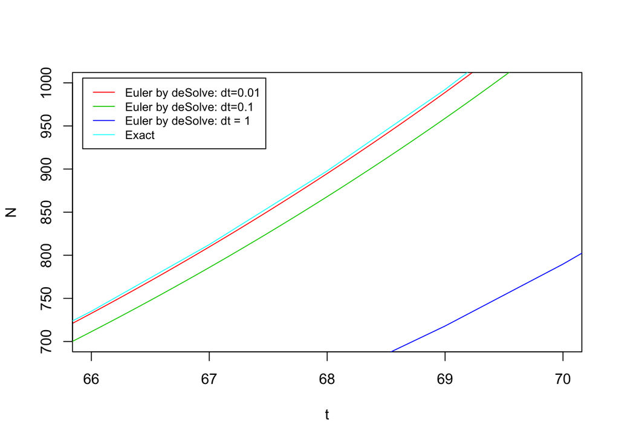

```r
plot(results_1[,1], results_1[,2], type = "l", col=2,
    xlab="t", ylab="N", xlim=c(66,70), ylim=c(700,1000))
lines(results_2[,1], results_2[,2], col=3)
lines(results_3[,1], results_3[,2], col=4)
lines(t, nt1, col=5)

legend("topleft", inset=0.02,
       legend = c("Euler by deSolve: dt=0.01", "Euler by deSolve: dt=0.1",
                  "Euler by deSolve: dt = 1", "Exact"),
       col=2:5, lty=1, cex=0.8)
```

**Q1.** Simulate the exponential growth model in deSolve with a few other integration methods, such as ode23 and ode45. For each, compare the simulation results with the exact solutions. Evaluate and compare the accuracy of these methods.

Hint: Use ?deSolve to find its usage.

#### Use integrator functions

Here, we illustrate the use of our own integrator functions, as described in Part 2B. We Use both the Euler method and the 4th order Runge-Kutta method (RK4).

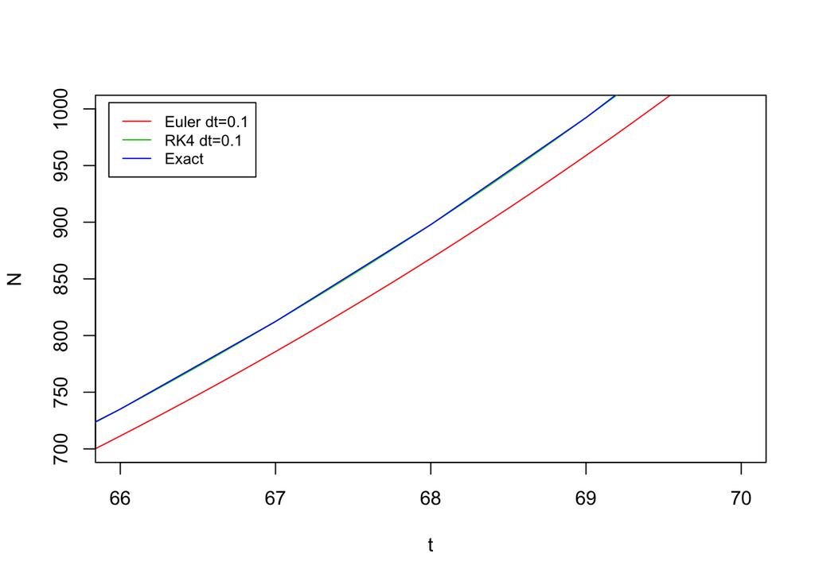

```r
dN <- function(t, N, r) { # define derivative function, Equation (1)
  return(r*N)
}

# Euler_single is a generic function of Euler method for a single ODE
Euler <- function(derivs, X0, t.total, dt, ...){
  # derivs: the function of the derivatives
  # X0: initial condition
  # t.total: total simulation time, assuming t starts from 0 at the beginning
  # dt: time step size
  t_all = seq(0, t.total, by=dt)
  n_all = length(t_all)
  X_all = numeric(n_all)
  X_all[1] = X0
  for (i in 1:(n_all-1)) {
    X_all[i+1] = X_all[i] + dt * derivs(t_all[i],X_all[i], ...)
  }
  return(cbind(t_all, X_all))   # the output is a matrix of t & X(t) for all time steps
}

# 4th order Runge-Kutta (RK4)
RK4 <- function(derivs, X0, t.total, dt, ...){
  # derivs: the function of the derivatives
  # X0: initial condition
  # t.total: total simulation time, assuming t starts from 0 at the beginning
  # dt: time step size
  t_all = seq(0, t.total, by=dt)
  n_all = length(t_all)
  X_all = numeric(n_all)
  X_all[1] = X0
  for (i in 1:(n_all-1)) {
    t_0= t_all[i]
    t_0.5 = t_0 + 0.5*dt
    t_1 = t_0 + dt
    k1 = dt * derivs(t_0,X_all[i], ...)
    k2 = dt * derivs(t_0.5,X_all[i] + k1/2, ...)
    k3 = dt * derivs(t_0.5,X_all[i] + k2/2, ...)
    k4 = dt * derivs(t_1,X_all[i] + k3, ...)
    X_all[i+1] = X_all[i] + (k1+2*k2+2*k3+k4)/6
  }
  return(cbind(t_all, X_all))   # the output is a matrix of t & X(t) for all time steps
}

X0 = 1; t.total = 100; dt = 0.1; r = 0.1
results_4 = Euler(derivs = dN, X0 = X0, t.total = t.total, dt = dt, r = r)
results_5 = RK4(derivs = dN, X0 = X0, t.total = t.total, dt = dt, r = r)

plot(results_4[,1], results_4[,2], type = "l", col=2,
    xlab="t", ylab="N", xlim=c(66,70), ylim=c(700,1000))
lines(results_5[,1], results_5[,2], col=3)
lines(t, nt1, col=4)

legend("topleft", inset=0.02,
       legend = c("Euler dt=0.1", "RK4 dt=0.1", "Exact"),
       col=2:4, lty=1, cex=0.8)
```

As shown above, with the same step size $dt = 0.1$, RK4 is much more accurate than the Euler method to model exponential growth for large $t$.

## Logistic growth

#### Analytical solution

The logistic equation considers the limits to growth. The ODE is

$$\begin{equation}
\frac{dN}{dt} = rN(1-\frac{N}{B}) \tag{3}
\end{equation}$$

Here, $r$ is the per capita growth rate, and $B$ is carrying capacity. The initial condition of Equation (3) is

$$N(t = 0) = N_0$$
This ODE can be solved analytically, with the solution

$$\begin{equation}
N = \frac{N_0 B}{N_0 + (B - N_0)e^{-rt}} \tag{4}
\end{equation}$$

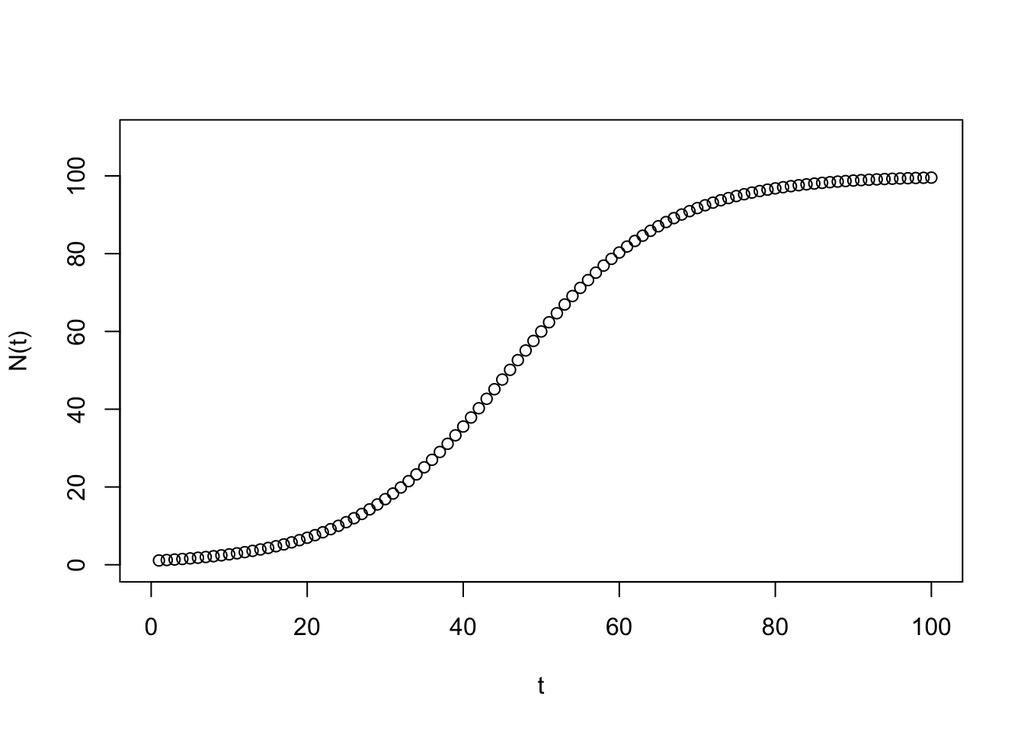

```r
logistic_exact <- function(t,r,B,N0) {   # the function to calculate logistic growth: exact solution
  return(N0*B/(N0+(B-N0)*exp(-r*t)))
}

N0 = 1; r = 0.1; B= 100
t = seq(1, 100, 1)   # all time points to be evaluated
nt2 = logistic_exact(t, r, B, N0)   # all N(t) values

plot(t, nt2, xlab="t", ylab="N(t)", xlim=c(0,100), ylim=c(0,110))
```

**Q2.** We set $B = 100$, $N_0 = 1$, and $r = 0.1$. Plot the logistic equation in R. Use deSolve (or, alternatively, use the above functions *Euler_Single* and *RK4*) to simulate Equation (3).

1. Compare the simulation results with the exact solutions (shown above). When (in terms of time $t$) does the algorithms generate largest errors?
2. Now consider the initial condition as $N_0 = 200$. Perform simulation to find $N(t)$.